# Jeewan Gamage | Editable GitHub Website

# Jeewan *Gamage*

Advancing the science of soil organic matter, water function, and spectroscopic measurement in agricultural systems, from mechanisms to field-scale translation.

Explore research View publications

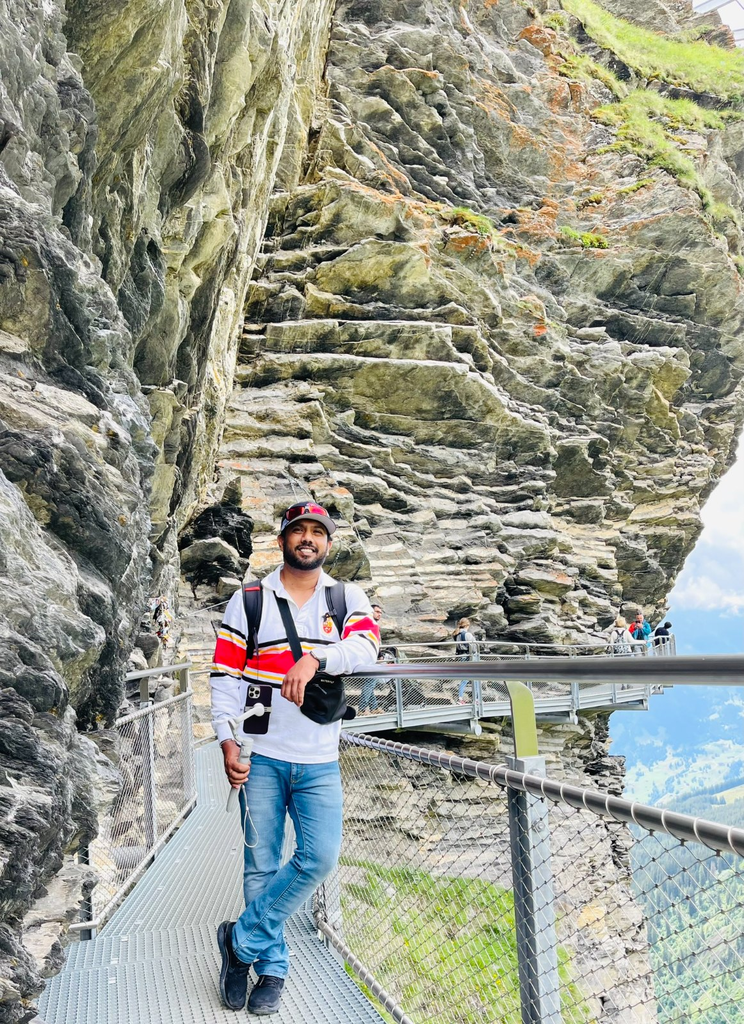

About

## Soil Scientist at the Plant–Water Nexus

[figure not shown]

I am a postdoctoral researcher working in soil science, with a focus on soil organic matter chemistry, density fractionation, and spectroscopic approaches including DRIFT and NMR.

My work connects molecular-level understanding of soil carbon with practical questions in forage systems, grazing management, and soil water function.

My broader goal is to develop mechanistic and field-relevant insight into how management influences active and stable soil carbon pools.

Research

## Research themes

### Soil organic matter fractions

Studying POM, MAOM, and bulk soil responses to management using fractionation and elemental analysis.

### Spectroscopy and structural chemistry

Using DRIFT, solid-state NMR, and related approaches to understand molecular shifts in soil carbon.

### Forage systems and water function

Linking management, soil organic matter, and water-related function in agricultural systems.

Publications

## Selected outputs

2024

### Evidence for the formation of fused aromatic ring structures in an organic soil profile in the early diagenesis

Jeewan Gamage, Paul Voroney, Adam Gillespie, Andy Lo & James Longstaffe

Nature Scientific Reports

Paper

2024

### Chemical composition of soil humin in an organic soil profile

Jeewan Gamage, Paul Voroney, Adam W. Gillespie, James Longstaffe

Applied Geochemistry

Paper

2026

### Chemical Composition of Soil Organic Carbon Under Adaptive Multi-Paddock Grazing and Other Land Uses: A Comparative 13C NMR Study

Jeewan Gamage, Jessica J. Mehre, Adam Gillespie, Kim Schneider

Geoderma

Paper

2023

### Role of organic farming for achieving sustainability in agriculture

Ashoka Gamage, Ruchira Gangahagedara, Jeewan Gamage, Nepali Jayasinghe, Nathasha Kodikara, Piumali Suraweera, Othmane Merah

Farming System

Paper

2024

### Advancing sustainability: The impact of emerging technologies in agriculture

Ashoka Gamage, Ruchira Gangahagedara, Shyamantha Subasinghe, Jeewan Gamage,Chamini Guruge, Sera Senarathne, Thevin Randika, Chamila Rathnayake, Zammil Hameed, Terrence Madhujith, Othmane Merah

Current Plant Biology

Paper

Gallery

## Photos

[figure not shown]

[figure not shown]

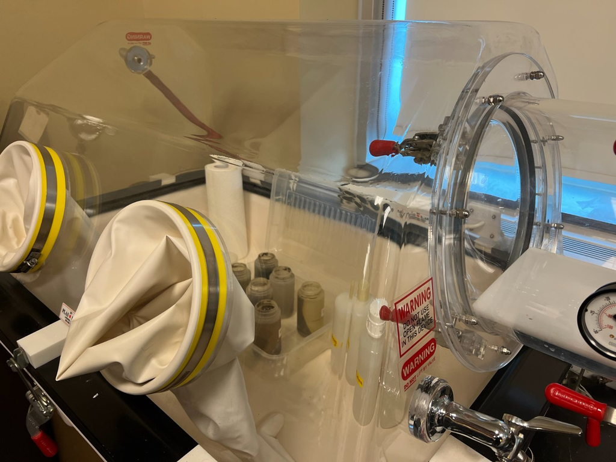

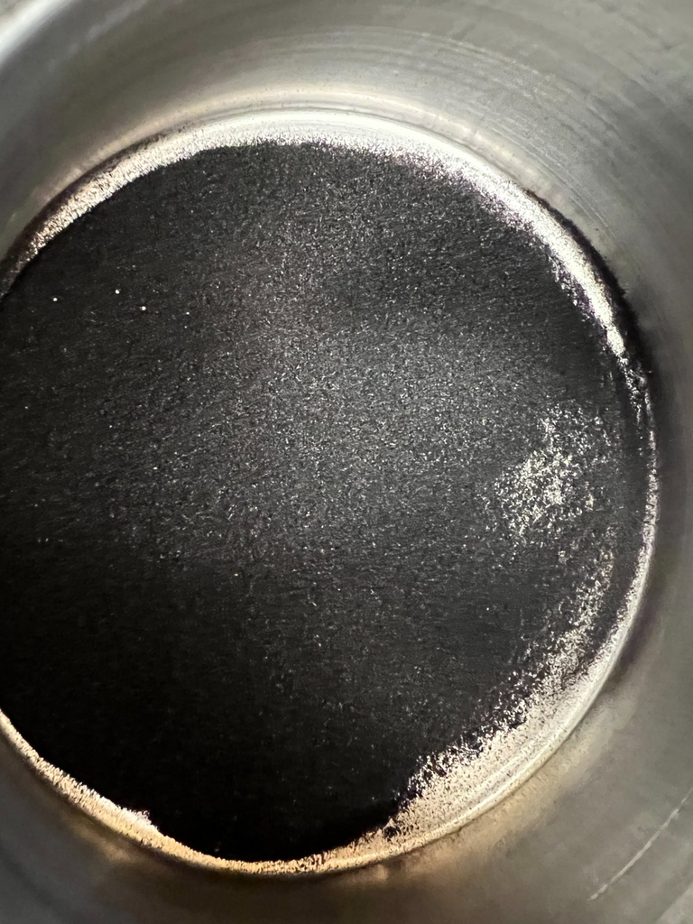

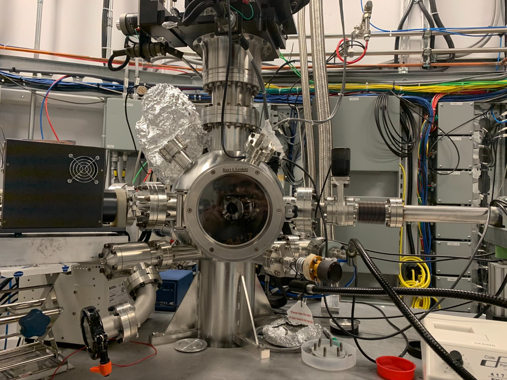

Contact

## Get in touch

Jeewan Gamage, Department of Plant Agriculture, University of Guelph

**Email:** hkumara@uoguelph.ca

**Location:** Guelph, Ontario, Canada